# DS養成講座 Jリーグ観客動員数を予測せよ！

Shinji KAWASOE

Data : 2017-11-22

# 1 概要

コンペの内容  
https://deepanalytics.jp/compe/27

本コンテストでは、2012年～2014年シーズン前半までのデータを使って、  
「2014年後半戦J1,J2全試合の観客動員数を予測するモデル」  
を作成していただきます。

# 2 取り組みの方針

モデル作成用のカラム

```r
library(knitr)
param <- c("capa", "pre_rank", "media", "stage", "section", "home_team", "away_team","hour","week","rain")
explain <- c("スタジアムの収容人数", "前節のランキング", "tv局数", "開催大会", "節", "ホームチーム", "アウェイチーム", "開始時刻", "1(土日祝)、0(平日)", "1(雨)、0(雨以外)")
cols <- data.frame(Parameter=param, Explain=explain)

kable(cols)
```

| Parameter | Explain |
| --- | --- |
| capa | スタジアムの収容人数 |
| pre_rank | 前節のランキング |
| media | tv局数 |
| stage | 開催大会 |
| section | 節 |
| home_team | ホームチーム |
| away_team | アウェイチーム |
| hour | 開始時刻 |
| week | 1(土日祝)、0(平日) |
| rain | 1(雨)、0(雨以外) |

# 3 データ加工

```r
## 使用ライブラリ
library(tidyverse)
## データ読込(結合したデータ)
train<-read.csv("../data/train_new.csv", #読込ファイル
                header=TRUE, #読込データのヘッダー有無
                stringsAsFactors=FALSE #文字列の読込時の型指定(character)
)
test<-read.csv("../data/test_new.csv",
               header=TRUE,
               stringsAsFactors=FALSE)
```

## 3.1 データ加工を全データに実施するため、trainとtestを結合する。

```r
test$y <- NA
combi <- rbind(train,test)

## 今は使わないカラムを減らして、少し見やすくする。後で使うかも。
combi <- combi %>%
    dplyr::select(-(home_01:home_11),-(away_01:away_11))
```

## 3.2 開催節を分割する。

時系列データとして扱い易いように変更する。  
開催節(match)を節(section)と連番(seq)に分ける。

```r
## 節を加工
combi <- combi %>%
    dplyr::mutate(match = purrr::map(match, stringi::stri_trans_nfkc)) %>%
    dplyr::mutate(match = str_replace_all(match, pattern = "[第日]", replacement = "")) %>%
    tidyr::separate(match, into = c('section','seq'), sep="節") %>%
    dplyr::mutate(section = as.numeric(section) ,
                  seq = as.numeric(seq))
```

## 3.3 勝点とランキングを考える。

### 3.3.1 勝点を算出する。

- 勝点は各節でTeam単位に出力されるため、home, awayの両方を計算する必要がある。
- 自分と相手のscoreを比較して、勝点(3,1,0)を算出する。

```r
## home, awayでレコードを分ける
combi_split <- combi %>%
    tidyr::gather(`home`,`away`, key="type", value="team") %>%
    dplyr::mutate(my_score = if_else(type=="home", home_score, away_score),
                  opponent_score = if_else(type=="home", away_score, home_score))

## 勝点の算出
combi_split <- combi_split %>%
    dplyr::mutate(victory_point = 0,
                  victory_point = if_else(my_score > opponent_score, 3, victory_point),
                  victory_point = if_else(my_score == opponent_score, 1, victory_point))
```

### 3.3.2 得失点を算出する。

- チームごと(group_by)に、自分と相手のscoreを減算して、その結果を累積(Cumulative)する。
- 勝点の累積を算出する。

```r
## 得失点、勝点の累積を算出
combi_point <- combi_split %>%
    dplyr::group_by(year, team) %>%
    dplyr::arrange(year,section,seq) %>%
    dplyr::mutate(cum_vp = cumsum(victory_point)) %>%
    dplyr::mutate(cum_score = cumsum(my_score - opponent_score)) %>%
    dplyr::ungroup(.)
```

### 3.3.3 順位を算出する。

- 節で切りTeamの全ての勝点と得失点でrankingを取る。
  - rank : 節単位のランキング
  - desc_rank : 逆順でのランキング(下位が上位)
  - pre_rank : 前節のランキング

```r
combi_rank <- combi_point %>%
    dplyr::group_by(year, section, stage) %>%
    dplyr::mutate(rank = min_rank(cum_vp)) %>%
    dplyr::mutate(desc_rank = if_else(stage == "Ｊ１", 34 - rank, 42 - rank)) %>%
    dplyr::ungroup(.)

combi_pre_rank <- combi_rank %>%
    dplyr::group_by(year, team) %>%
    dplyr::mutate(pre_rank = lag(rank)) %>%
    dplyr::ungroup(.) %>%
    dplyr::mutate(pre_rank = ifelse(is.na(pre_rank),0, pre_rank))

## pre_rankにNAが含まれている。
## 後述する分析結果より、pre_rankがyに対して負の相関あり？と考えて、0を投入する。

combi_pre_rank %>%
    dplyr::filter(team == "鹿島アントラーズ") %>%
    glimpse
```

```
## Observations: 102
## Variables: 30
## $ id             <int> 13994, 14003, 14013, 14028, 14036, 14040, 14052...
## $ y              <int> 18250, 19010, 14349, 22126, 23507, 19279, 12110...
## $ year           <int> 2012, 2012, 2012, 2012, 2012, 2012, 2012, 2012,...
## $ stage          <chr> "Ｊ１", "Ｊ１", "Ｊ１", "Ｊ１", "Ｊ１", "Ｊ１", "Ｊ１", "Ｊ１",...
## $ section        <dbl> 1, 2, 3, 4, 5, 6, 7, 8, 9, 10, 11, 12, 13, 14, ...
## $ seq            <dbl> 1, 1, 1, 1, 1, 1, 1, 1, 1, 1, 1, 1, 2, 1, 1, 1,...
## $ gameday        <chr> "03/10(土)", "03/17(土)", "03/24(土)", "03/31(土)",...
## $ time           <chr> "14:04", "14:04", "13:04", "19:03", "17:04", "1...
## $ stadium        <chr> "ユアテックスタジアム仙台", "県立カシマサッカースタジアム", "エディオンスタジアム広島...
## $ tv             <chr> "スカパー／ｅ２／スカパー光／ＮＨＫ総合", "スカパー／ｅ２／スカパー光／ＮＨＫ水戸", "...
## $ home_score     <int> 1, 0, 2, 0, 1, 1, 3, 5, 3, 0, 3, 7, 1, 2, 1, 1,...
## $ away_score     <int> 0, 1, 0, 0, 3, 2, 2, 0, 0, 0, 0, 0, 2, 3, 1, 1,...
## $ weather        <chr> "雨", "雨", "曇時々晴", "曇のち雨", "晴のち曇", "雨", "曇時々晴", ...
```

[output cut: 17 more lines]

## 3.4 その他の加工

### 3.4.1 テレビ局の数の導出

相関がある様には見えない..

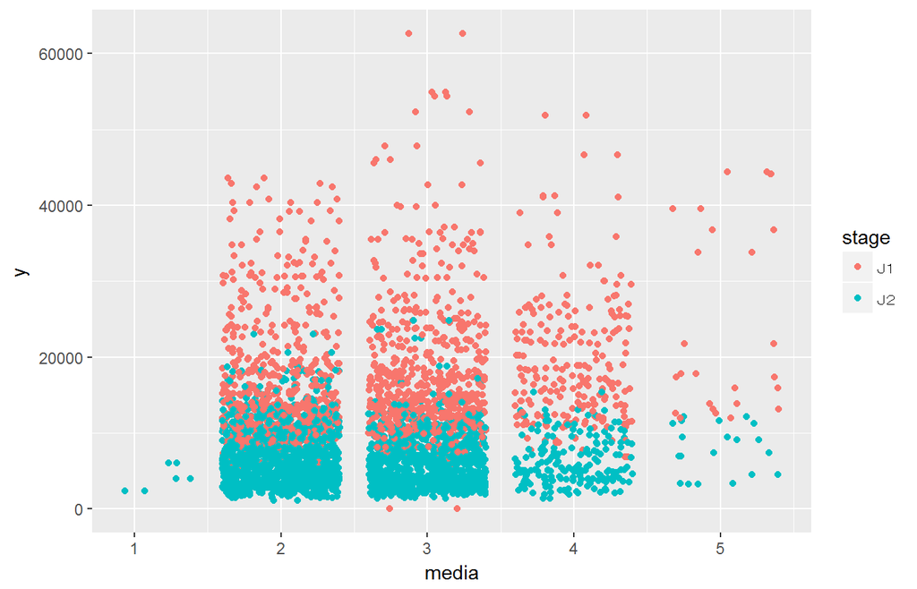

```r
combi_tv <- combi_pre_rank %>%
    dplyr::mutate(media = str_count(tv,"／") + 1)

combi_tv %>%
    ggplot(mapping = aes(x = media, y = y)) + geom_jitter(mapping = aes(colour = stage))
```

### 3.4.2 開始時間

評価方法が不明瞭。

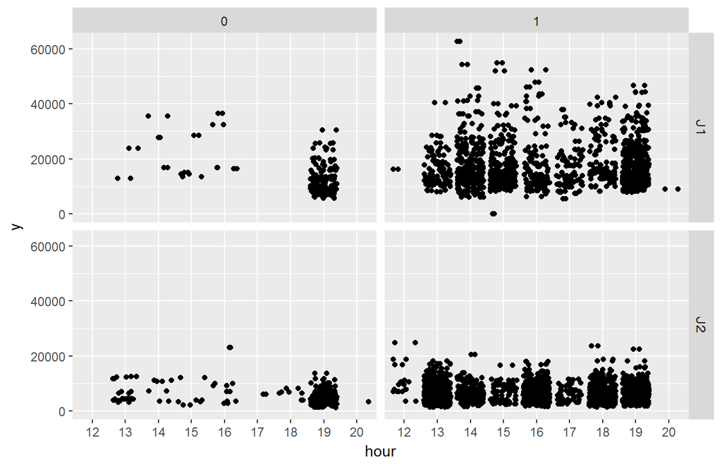

```r
combi_time <- combi_tv %>%
    dplyr::mutate(hour = str_sub(time, 1,2)) %>%
    dplyr::mutate(week = ifelse(str_detect(gameday,"[土日祝]"), 1, 0))

combi_time %>%
    ggplot(mapping = aes(x = hour, y = y)) +  geom_jitter() + facet_grid(stage ~ week)
```

### 3.4.3 天候

評価方法が不明瞭。

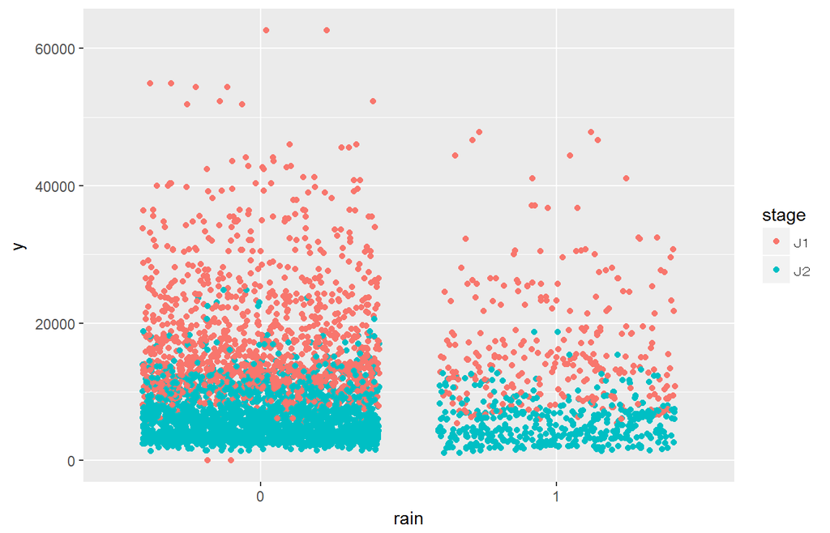

```r
combi_weather <- combi_time %>%
    dplyr::mutate(rain = as.factor(ifelse(str_detect(weather,"雨"), 1, 0)))

combi_weather %>%
    ggplot(mapping = aes(x = rain, y = y)) +  geom_jitter(mapping = aes(colour = stage))
```

```r
combi_mod <- combi_weather
```

## 3.5 trainとtestに分割する

```r
train <- combi_mod %>%
    dplyr::filter(!is.na(y))
test <- combi_mod %>%
    dplyr::filter(is.na(y))
```

# 4 Hold Outで検証

精度を見たいのでホールドアウト法により構築データと検証データに分ける  
2012-2013年を構築データとし、2014年の前半を検証データとする。

temparatureは相関がなさそうなので使わない。(2017.11.22講義資料より)

```r
train_train <- train %>%
    dplyr::filter(year < 2014)
train_test <- train %>%
    dplyr::filter(year == 2014) %>%
    dplyr::filter(home_team != "カマタマーレ讃岐") %>%
    dplyr::filter(away_team != "カマタマーレ讃岐")
## カマタマーレ讃岐は2014からのチームなので、train_testから除外

###使用変数の作成
#変数選択(目的変数, 収容人数, 前節ランキング)
lm_train<-dplyr::select(train_train, y, param)
lm_test<-dplyr::select(train_test, param)

###重回帰分析
#family:目的変数の確率分布とリンク関数の設定(今回は正規分布と恒等写像)
lm<-glm(y ~ ., data=lm_train, family=gaussian(link="identity"))

### testに当てはめ
## type="response"でリンク関数を当てはめる前の値が返ってくる
pred<-predict(lm, lm_test, type="response")

## typeが無指定だとリンク関数を当てはめた値が返ってくる
## link="log"であれば, exp(pred)で予測値を返すことができる

## 結果出す前に、home,away分割を戻す
train_test$pred <- pred

result <- train_test %>%
    dplyr::group_by(id) %>%
    dplyr::summarise(
               y = mean(y),
               pred = mean(pred)
           )
## RMSEの計算
sqrt(mean((result$y - result$pred)^2))
```

```
## [1] 4060.621
```

# 5 OPT投稿データ作成

テストデータに追加ファイルを使用しているので、投稿対象の試合に絞る。

```r
###使用変数の作成
#変数選択(目的変数, 収容人数, 前節ランキング)
lm_train<-dplyr::select(train, y, param)
lm_test<-dplyr::select(test, param)

###重回帰分析
#family:目的変数の確率分布とリンク関数の設定(今回は正規分布と恒等写像)
lm<-glm(y ~ ., data=lm_train, family=gaussian(link="identity"))

###testに当てはめ
#type="response"でリンク関数を当てはめる前の値が返ってくる
pred<-predict(lm, lm_test, type="response")

#typeが無指定だとリンク関数を当てはめた値が返ってくる
#link="log"であれば, exp(pred)で予測値を返すことができる

## testデータにAddしたレコードを除去する。

sample <- read_csv("../motodata/sample_submit.csv", col_names=c("id","pred"))
nrow(sample)
```

```
## [1] 313
```

```r
test$pred <- pred

###submit形式に整える
submit <- sample %>%
    dplyr::select(id) %>%
    dplyr::left_join(test, by="id") %>%
    dplyr::group_by(id) %>%
    dplyr::summarise(pred = mean(pred)) %>%
    dplyr::ungroup(.)


###CSV出力(ヘッダーなし)
write.table(submit, file="../submit/submit_20171121_1_lm.csv",
            quote=FALSE, sep=",", row.names=FALSE, col.names=FALSE)
```

結果(6,071 -> 6,048 -> 3,582)

# 6 データの考察

## 6.1 前節ランキング(pre_rank)は観客動員数(y)と相関があるのか？

ランクが引くい方が動員数が多い様だ。

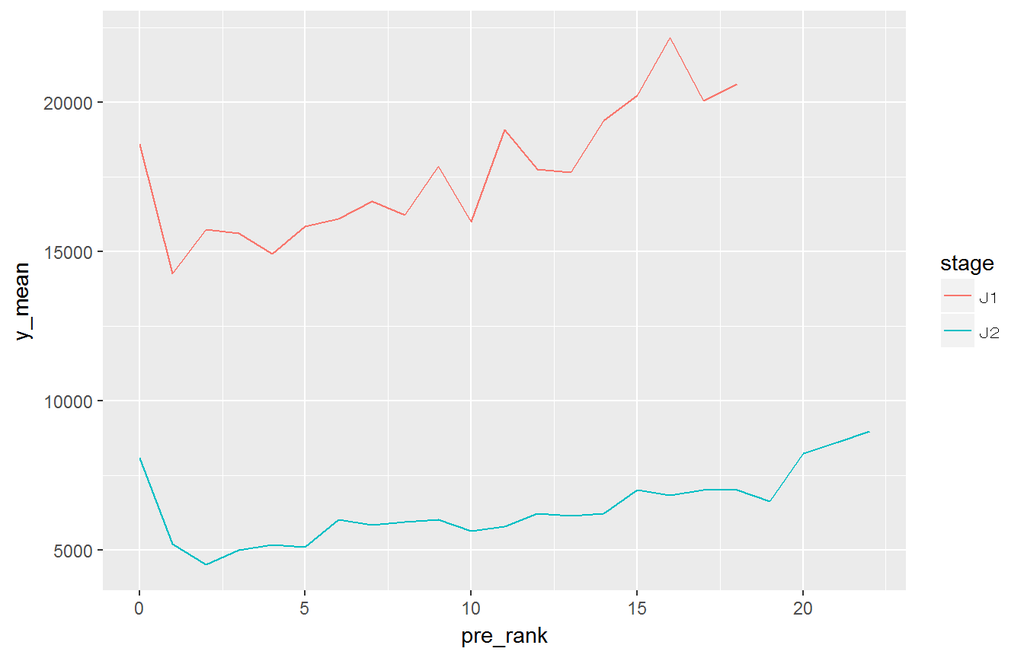

```r
train %>%
    dplyr::group_by(stage, pre_rank) %>%
    dplyr::summarise(y_mean = mean(y)) %>%
    dplyr::ungroup(.) %>%
    ggplot(., mapping=aes(x = pre_rank, y = y_mean)) + geom_line(mapping = aes(colour = stage))
```

## 6.2 対戦するチームの組合せによって集客が変わるのか？

年で若干異なる。傾向の有無までは判断できず。

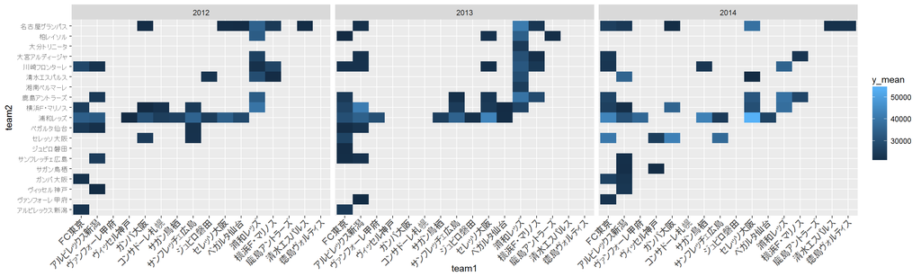

```r
train %>%
    dplyr::filter(stage == "Ｊ１") %>%
    dplyr::mutate(team1 = if_else(home_team < away_team, home_team, away_team),
                  team2 = if_else(home_team > away_team, home_team, away_team)) %>%
    dplyr::group_by(year, team1, team2) %>%
    dplyr::summarise(y_mean = mean(y)) %>%
    dplyr::ungroup(.) %>%
    dplyr::filter(y_mean > 20000) %>%
    ggplot(mapping=aes(x = team1, y = team2)) +
    geom_tile(mapping = aes(fill=y_mean)) +
    facet_grid(. ~ year) +
    theme(axis.text.x = element_text(angle = 45, hjust = 1))
```